# pm566-a3

Author

Stella Zhou

## Text mining

```r
library(readr)
library(dplyr)
library(tidytext)
library(ggplot2)
library(forcats)
library(tidyr)
pubmed <- read_csv("https://raw.githubusercontent.com/USCbiostats/data-science-data/master/03_pubmed/pubmed.csv")
```

```r
head(pubmed)
```

```
# A tibble: 6 × 2
  abstract                                                                 term
  <chr>                                                                    <chr>
1 "Background and aims: Many patients with coronavirus disease 2019 (COVI… covid
2 "Introduction: Contradictory data have been reported on the incidence o… covid
3 "This article aims at collecting all information needed for dentists re… covid
4 "OBJECTIVE. The objective of our study was to determine the misdiagnosi… covid
5 "Background: Much of the focus regarding the global pandemic of coronav… covid
6 "The World Health Organization (WHO) has issued a warning that, althoug… covid
```

1. Tokenize the abstracts and count the number of each token. Do you see anything interesting? Does removing stop words change what tokens appear as the most frequent? What are the 5 most common tokens for each search term after removing stopwords?

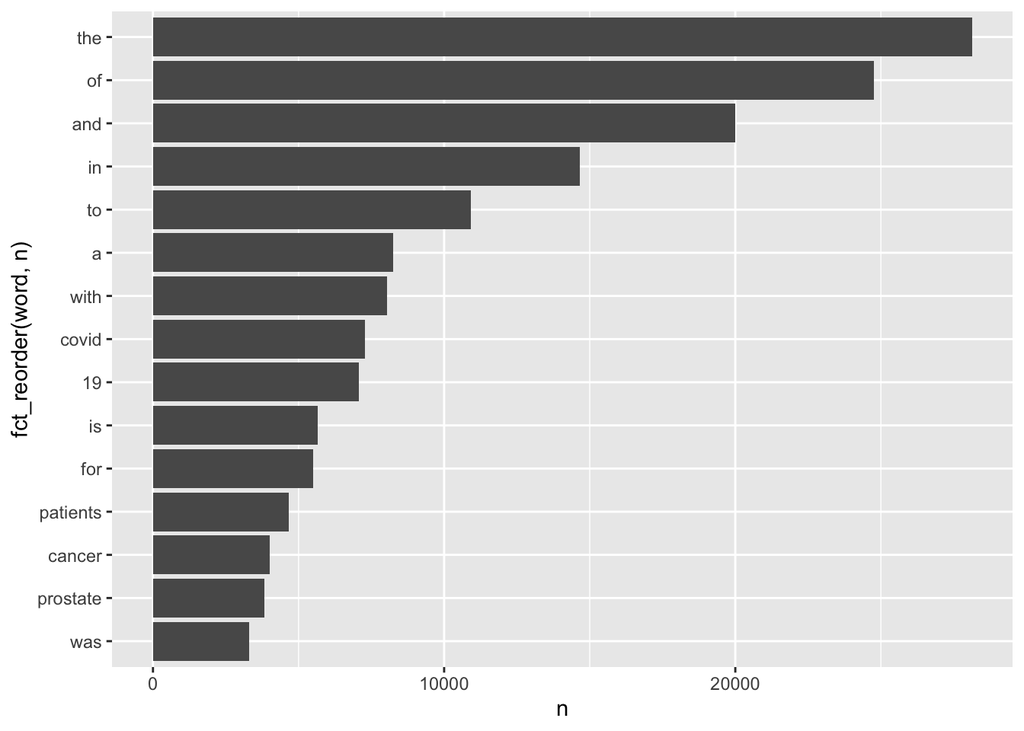

```r
pubmed %>%
  unnest_tokens(word, abstract) %>%
  count(word) %>%
  top_n(15, n) %>%
  ggplot(aes(n, fct_reorder(word, n))) +
  geom_col()
```

The top used words are stop words. To remove them, we do the following.

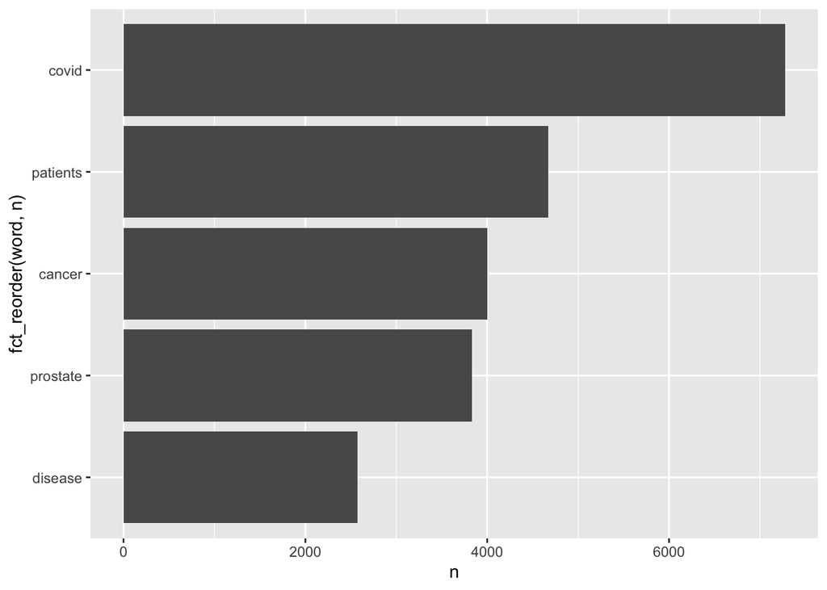

```r
pubmed %>%
  unnest_tokens(word, abstract) %>%
  count(word, sort = TRUE) %>%
  anti_join(stop_words, by = "word") %>%
  filter(!grepl(pattern = "^[0-9]+$", x = word)) %>%
  top_n(5) %>%
  ggplot(aes(x = n, y = fct_reorder(word,n))) +
    geom_col()
```

After removing stop words and numbers, the top five words are covid, patients, cancer, prostate, and disease.

2. Tokenize the abstracts into bigrams. Find the 10 most common bigrams and visualize them with ggplot2.

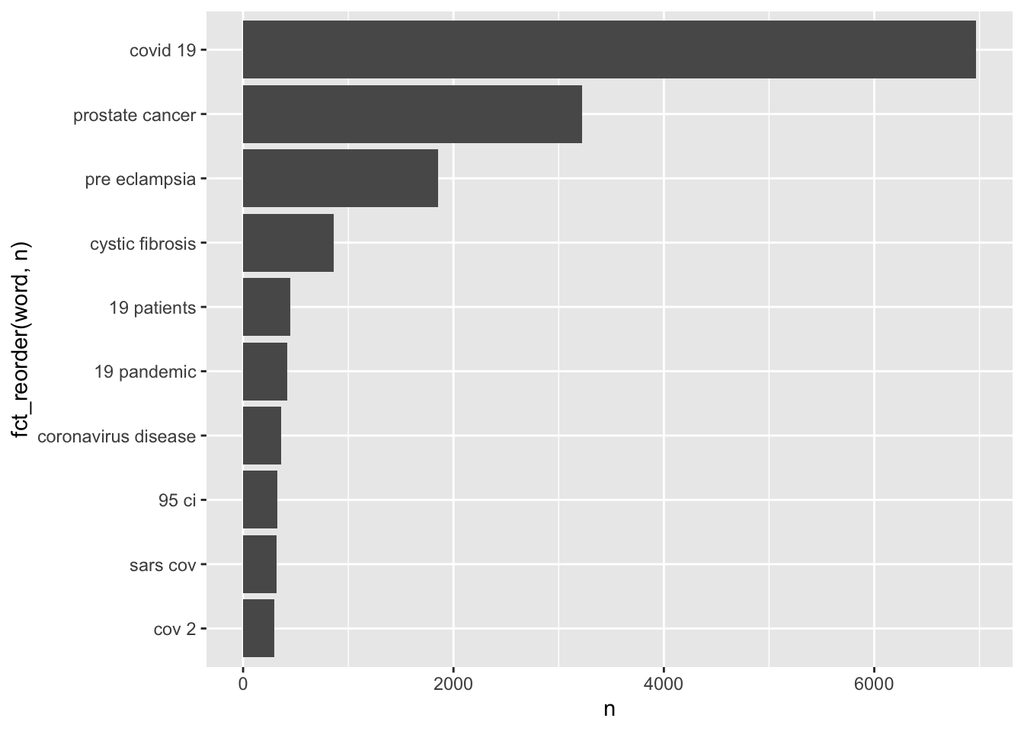

```r
pubmed %>%
  unnest_ngrams(word, abstract, n = 2) %>%
  separate (word, c("word1", "word2"),sep = " ") %>%
  anti_join(tidytext::stop_words, by =c("word1" = "word")) %>%
  anti_join(tidytext::stop_words, by =c("word2" = "word")) %>%
  unite(word, word1, word2, sep = " ") %>%
  count(word, sort = T) %>%
  top_n(10,n) %>%
  ggplot(aes(n, fct_reorder(word, n)))+
  geom_col()
```

The most frequent bigrams are covid 19, prostate cancer, and pre eclampsia.

3. Calculate the TF-IDF value for each word-search term combination (here you want the search term to be the "document"). What are the 5 tokens from each search term with the highest TF-IDF value? How are the results different from the answers you got in question 1?

```r
pubmed %>%
  unnest_tokens(output = word, input = abstract) %>%
  count(word, term) %>%
  bind_tf_idf(word, term, n) %>%
  arrange(desc(tf_idf)) %>%
  group_by(term) %>%
  top_n(5,tf_idf) %>%
  arrange(desc(term))
```

```
# A tibble: 25 × 6
# Groups:   term [5]
   word          term                n      tf   idf  tf_idf
   <chr>         <chr>           <int>   <dbl> <dbl>   <dbl>
 1 prostate      prostate cancer  3832 0.0312  1.61  0.0502
 2 androgen      prostate cancer   305 0.00248 1.61  0.00400
 3 psa           prostate cancer   282 0.00230 1.61  0.00369
 4 prostatectomy prostate cancer   215 0.00175 1.61  0.00282
 5 castration    prostate cancer   148 0.00120 1.61  0.00194
 6 eclampsia     preeclampsia     2005 0.0143  1.61  0.0230
 7 preeclampsia  preeclampsia     1863 0.0133  1.61  0.0214
 8 pregnancy     preeclampsia      969 0.00690 0.511 0.00353
 9 maternal      preeclampsia      797 0.00568 0.511 0.00290
10 gestational   preeclampsia      191 0.00136 1.61  0.00219
# ℹ 15 more rows
```

The highest TF-IDF value for prostate cancer also includes androgen, psa, prostatectomy, and castration; preclampsia includes pregnancy and maternal; meningitis includes meningeal and pachymengitis, cystic fibrosis includes CF and ctfr. The results are similar to 1 but provides more meaningful related words.